# Risk of Ruin Theory and Simulation

davegoblue

April 30, 2016

## Background and Objective

Risk of ruin is a concept derived from playing a game out to infinite trials. If the lowest point reached in the game exceeds the bankroll, then the player is “ruined” (the game ends). If not, the bankroll will eventually tend towards infinite as the number of trials tends towards infinite.

A simplified game is one in which every outcome is an integer, with the worst possible outcome being -1 (loss of a single unit). In that case, if rr is the risk of ruin with a single unit, then rr^n is the risk of ruin with n units. This is because to be ruined with 2 units is really to be ruined with 1 unit twice (the recurison goes out to infinite).

This program calculates the theoretical risk of ruin for a set of inputs (all integers, worst outcome -1), then runs simulations to compare against the theory.

## Analysis

#### *Function to read in the base outcomes file*

The first function creates a base outcomes file. It will read the outcomes file (probabilities summing to 1 and associated outcomes) provided:

```r
getBaseOutcomes <- function(myFileName="BaseOutcomes.csv", forceEQ=FALSE) {

    if (file.exists(myFileName)) {
        baseOutcomes <- read.csv(myFileName,stringsAsFactors = FALSE)
        if (ncol(baseOutcomes) != 2) { stop("Error in CSV file, should have exactly 2 columns") }
        colnames(baseOutcomes) <- c("probs","outcomes")
    } else {
        baseOutcomes <- data.frame(probs=c(0.01,0.02,0.05,0.18,0.24,0.50),outcomes=c(10,5,2,1,0,-1))
    }

    baseOutcomes <- baseOutcomes[baseOutcomes$probs != 0,] ## Can have zeroes as inputs -- ignore those

    if ( forceEQ ) {
        pDelta <- sum(baseOutcomes$probs) - 1
        if ( abs(pDelta) < 0.0000001 &
             abs(pDelta) / baseOutcomes[nrow(baseOutcomes),]$probs < 0.1
        )
        {
            print(paste0("Modifying probablities ",paste0(baseOutcomes[nrow(baseOutcomes),],collapse=" ")))
            baseOutcomes[nrow(baseOutcomes),]$probs <- baseOutcomes[nrow(baseOutcomes),]$probs - pDelta
            print(paste0("New probablities ",paste0(baseOutcomes[nrow(baseOutcomes),],collapse=" ")))
        }
    }

    if (sum(baseOutcomes$probs)!=1 | min(baseOutcomes$probs) < 0 |
        sum(is.na(baseOutcomes$probs)) > 0 | sum(is.na(baseOutcomes$outcomes)) > 0) {
        stop("Please resolve the issue with inputs for probs and outcomes, aborting")
    }

    ## Store the original value read in as outcomes
    baseOutcomes$oldOutcomes <- baseOutcomes$outcomes

    baseMean <- sum(baseOutcomes$probs*baseOutcomes$outcomes)
    baseVar <- sum(baseOutcomes$probs*(baseOutcomes$outcomes-baseMean)^2)

    print(paste0("Probabilities sum to 1.  Outcomes has mean ",format(baseMean,digits=3),
                 " and variance ",format(baseVar,digits=3)))

    return(baseOutcomes)
}
```

#### *Function to modify the base outcomes file*

The modification function converts the base outcome file to simulate the addition of a “cash back” component. The idea is that if the player enjoys a 1% cash back, this can be pseudo-simulated by taking 1% probability away from -1 and moving it to 0. There are some issues with this approach, particularly for small bankrolls, but it vastly simplifies some of the processing. The simulations will be to test the appropriateness of this simplification.

```r
modBaseOutcomes <- function(baseOutcomes=baseOutcomes, nAddOnePer) {

    ## Place in the random additions component
    baseOutcomes$oldProbs <- baseOutcomes$probs

    ## Create a new row that changes the -1 to 0
    if (nAddOnePer > 0 & baseOutcomes[nrow(baseOutcomes),"probs"] > 1/nAddOnePer) {
        baseOutcomes <- rbind(baseOutcomes, baseOutcomes[nrow(baseOutcomes),])
        baseOutcomes[nrow(baseOutcomes)-1,]$outcomes <- baseOutcomes[nrow(baseOutcomes)-1,]$outcomes + 1
        baseOutcomes[nrow(baseOutcomes)-1,]$probs <- 1/nAddOnePer
        baseOutcomes[nrow(baseOutcomes)-1,]$oldProbs <- 0

        ## Fix the bottom row accordingly
        baseOutcomes[nrow(baseOutcomes),]$probs <- baseOutcomes[nrow(baseOutcomes),]$probs - 1/nAddOnePer

    } else {
        print(paste0("No modifications due to nAddOnePer=",nAddOnePer,
                     " and last row prob=",baseOutcomes[nrow(baseOutcomes),"probs"]
                     )
              )
    }

    ## Report on changes in metrics
    oldMean <- sum(baseOutcomes$oldProbs * baseOutcomes$outcomes)
    newMean <- sum(baseOutcomes$probs * baseOutcomes$outcomes)
    oldVar <- sum(baseOutcomes$oldProbs * baseOutcomes$outcomes^2) - oldMean^2
    newVar <- sum(baseOutcomes$probs * baseOutcomes$outcomes^2) - newMean^2

    print(paste0("Means have shifted from ", round(oldMean,5), " to ", round(newMean,5)))
    print(paste0("Variance has shifted from ", round(oldVar,2), " to ", round(newVar,2)))

    return(baseOutcomes)

}
```

#### *Function to calculate risk of ruin by way of polynomial*

In this simplified scenario, we have only integer outcomes with the worst outcome being -1. This allows for calculating the risk of ruin by way of a polynomial. In a simplified example, suppose there is a 30% probabilty of -1, 20% probability of 0, and a 50% probability of +1. Then:

- Ruin on the first hand is 30%
- Re-do from the same position is 20%
- Move to two units (if rr is ruin with 1 unit, then rr^2 is ruin with 2 units) is 50%

Then rr = 30% (lose right away) + 20% * rr (push right away) + 50% * rr^2 (bankroll better by one), which reduces to 50% * rr^2 - 80% * rr + 30% = 0 or rr^2 - 160% * rr + 60% = 0. By the quadratic equation then:

- rr = [160% +/- sqrt(160%^2 - 4 * 1 * 60%)] / (2 * 1)
- rr = [160% +/- sqrt(256% - 240%)] / 2
- rr = [160% +/- sqrt(16%)] / 2
- rr = [160% +/- 40%] / 2
- rr = 100% (trivially, rr=1 will solve any polynomial where p sum to 1) or rr = 60% (the more interesting solution)
- Checking rr=60%, this means 60% = 30% + 20% * 60% + 50% * 60%^2 = 30% + 12% + 18% = 60% (TRUE)

The problem is identical no matter the number of polynomial terms, provided that all outcomes are integers and the worst outcome is -1. Since it is difficult to solve high-order polynomials, this program uses sequential testing of possible rr to find the non-trivial solution for a set of inputs.

```r
testSeqP <- function(pVec, nMax, nStart=0, nEnd=1) {

    mtxTest <- matrix(data=rep(-9, 2*(nBuckets+1)), nrow=(nBuckets+1))

    probNeg <- pVec[pVec$outcomes == -1, ]$probs
    posProbs <- pVec[pVec$outcomes >= 0, ]

    for (intCtr in 0:nMax) {
        testP <- nStart + (intCtr/nMax)*(nEnd - nStart)
        mtxTest[intCtr+1, 1] <- testP
        myRuin <- probNeg

        for (intCtr2 in 1:nrow(posProbs)) {
            myRuin <- myRuin + posProbs[intCtr2,"probs"] * (testP ^ (posProbs[intCtr2,"outcomes"] + 1) )
        }

        mtxTest[intCtr+1, 2] <- myRuin
    }

    return(mtxTest)
}
```

#### *Function to simulate multiple trials of multiple hands given a probability vector*

This function is for simulating many hands across many trials and reporting the minimum reached. Assuming the game is positive EV and the number of hands is high enough, the distribution of minima should be a direct input in to the risk of ruin for any given bankroll. The function does several things:

- Converts the probability vector to a CDF for ease of later findInterval
- Splits the number of hands to reduce the memory requirements (trying to have no more than 40 million elements stored in the matrix at any given time)
- Initializes two vectors at zero for each trial, one storing the “last” data and one storing the “minimum” data
- Loops through each of the splits of data, pulling random numbers, using findInterval to pull out a result, calculates a cumulative sum adding cash-back as appropriate, adds the existing “last” vector to the new cumulative sum, and updates the “last” vector (always) as well as the “minimum” vector (if the new minima is lower than the existing minima based on this split

```r
calcOutcomes <- function(pdfFrame, cb=0, roughMaxN=4e+07) {

    myCDF <- numeric(nrow(pdfFrame)+1)
    myCDF[1] <- 0

    for ( intCtr in 1:nrow(pdfFrame) ) {
        myCDF[intCtr+1] <- myCDF[intCtr] + pdfFrame$probs[intCtr]
    }

    print(myCDF)

    ## nTrials and nPerTrial will be found in global environment
    ## Determine whether to split the processing
    nSplit <- ceiling(nTrials*nPerTrial/roughMaxN)
    print(paste0("Splitting in to ", nSplit," pieces each of roughly ",
                 round(roughMaxN/1000000,1)," million trials with (cb=", round(cb,4),")"
                 )
          )
    nPerSub <- ceiling(nPerTrial / nSplit) ## Allow a very slight round up
    print(paste0("Each sub-split will contain ",nPerSub," trials"))

    ## Initialize two vectors for storing data
    vecLast <- rep(0, nTrials) ## Will hold the current last value by trial
    vecMin <- rep(0, nTrials) ## Will hold the current minimum value by trial

    for (splitCtr in 1:nSplit) {
        mtxTemp <- matrix(pdfFrame$outcomes[findInterval(matrix(data=runif(nTrials * nPerSub, 0, 1),
                                                                nrow=nPerSub, ncol=nTrials
                                                                ), myCDF, rightmost.closed=TRUE
                                                         )
                                           ], nrow=nPerSub, ncol=nTrials
                          )

        mtxTemp <- apply(mtxTemp, 2, FUN=cumsum)

        if (cb > 0) {
            for (intCtr in 1:nrow(mtxTemp)) {
                ## Very slightly imperfect (potentially) around the edges of nSplit - ignored
                mtxTemp[intCtr, ] <- mtxTemp[intCtr, ] + floor(cb*intCtr)
            }
        }

        ## Add whatever was last to each row of the matrix from this run
        mtxTemp <- mtxTemp + matrix(data=rep(vecLast, nPerSub), nrow=nPerSub, ncol=nTrials, byrow=TRUE)

        ## Store the last row (after adjustment above) from this run back to vecLast
        vecLast <- mtxTemp[nrow(mtxTemp), ]

        ## Find the minimum from this run, keep if worse than previous minima
        ## Keep score of where these are occuring
        vecTemp <- pmin(apply(mtxTemp, 2, FUN=min), vecMin, 0)
        newMin <- sum(vecTemp < vecMin)
        vecMin <- vecTemp

        ## Report back on progress
        print(paste0("Finished sub-split #", splitCtr," with ",newMin," new minima"))
    }

    return(vecMin)
}
```

#### *Calculate the start time and run the function to get an outcomes vector*

The start time is calculated to understand overall performance, and the outcomes file is read and processed.

```r
startTime <- proc.time()

## Step 1: Read in the outcomes file
baseOutcomes <- getBaseOutcomes(myFileName="Play001Outcomes.csv",forceEQ=TRUE)
```

```
## [1] "Modifying probablities 0.54543467 -1"
## [1] "New probablities 0.54543466 -1"
## [1] "Probabilities sum to 1.  Outcomes has mean -0.00456 and variance 19.5"
```

```r
## Step 2: Modify the base outcomes file
nAddOnePer <- 100 ## Cash back is 1/nAddOnePer
baseOutcomes <- modBaseOutcomes(baseOutcomes=baseOutcomes, nAddOnePer=nAddOnePer)
```

```
## [1] "Means have shifted from -0.00456 to 0.00544"
## [1] "Variance has shifted from 19.52 to 19.51"
```

```r
## Step 3: Aggregate and keep only probs and outcomes
useProbs <- aggregate(probs ~ outcomes, data=baseOutcomes, FUN=sum)
if (sum(useProbs$outcomes == -1) != 1 |
    sum(useProbs$outcomes < 0) != 1 |
    sum(useProbs$outcomes == 0) != 1
    ) {
        stop("Error: Algorithm will not work given these inputs")
    }
```

#### *Calculate theoretical risk of ruin using two runs through testSeqP*

The thepretical risk of ruin is calculated using the polynomial approximation. The algorithm takes two passes, first looking across [0,1] to find the best small interval, then looking only within that tiny interval. The best solution for risk of ruin is reported, along with a graph showing that this point achieves a polynomial solution (f(x) - x = 0).

```r
## Step 4: solve for testP where testP is raised to each of the outcomes with prob
## Step 4a: First iteration (defaults to between 0 and 1)
nBuckets <- 4000
mtxResults <- testSeqP(pVec=useProbs, nMax=nBuckets)

## Step 4b: Find locations of any column1 >= column2 (that is the crossover point)
posDelta <- which(mtxResults[,1] >= mtxResults[,2])

## Step 4c: Find the appropriate starting point for a second run through the data
if (length(posDelta)==0 | (length(posDelta)==1 & posDelta[1]==(nBuckets+1) ) ) {
    ## Failed to find any, search starting with the second last element of mtxResults
    newStart <- mtxResults[nBuckets, 1] ## Note that there are nBuckets+1 elements; this is second-last
    newEnd <- mtxResults[nBuckets+1, 1]
} else {
    ## Found at least one, take the earliest instance, and start from it minus 1
    newStart <- mtxResults[posDelta[1]-1, 1]
    newEnd <- mtxResults[posDelta[1]+1, 1]
}


## Step 4d: Second iteration (give it the new end points)
mtxResults <- testSeqP(pVec=useProbs, nMax=nBuckets, nStart=newStart, nEnd=newEnd)


## Step 4e: Print the best value found
myBest <- which.min(abs(mtxResults[-(nBuckets+1),1]-mtxResults[-(nBuckets+1),2]))
mtxResults[myBest,]
```

```
## [1] 0.9993649 0.9993649
```

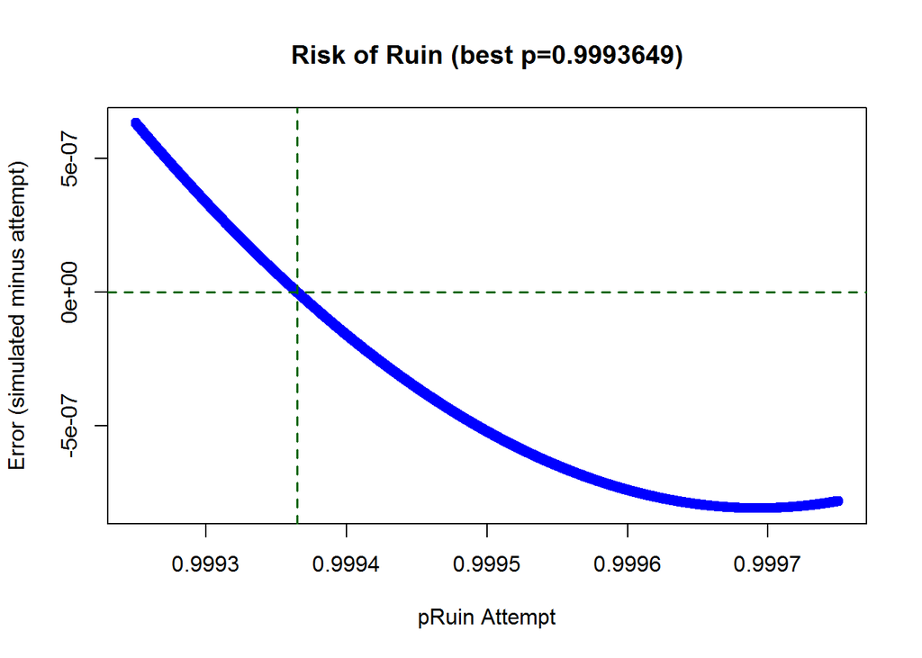

```r
rr1 <- mtxResults[myBest, 1]
plot(mtxResults[,1], mtxResults[,2]-mtxResults[,1], col="blue", xlab="pRuin Attempt",
     ylab="Error (simulated minus attempt)",
     main=paste0("Risk of Ruin (best p=", round(rr1,7), ")")
     )
abline(h=0, v=mtxResults[myBest,1], lty=2, lwd=1.5, col="dark green")
```

```r
print("Calculated theoretical risk of ruin for these inputs:")
```

```
## [1] "Calculated theoretical risk of ruin for these inputs:"
```

```r
print(proc.time() - startTime)
```

```
##    user  system elapsed
##    1.89    0.06    1.95
```

So, for a bankroll of n, we estimate risk of ruin to be rr1^n and log10(risk of ruin) to be n * log10(rr1).

#### *Simulate using two methods*

Global parameters are set, then the first simulation is run assuming the directly updated probabilities:

```r
## Step 5: Simulate with actual random draws (1000 trials of 10000 hands)
nTrials <- 2000 ## Each trial is a column
nPerTrial <- 3000000 ## Each row will be a cumulative outcome

## Step 5a: Run it straight up with the new probabilities
vecMinNew <- calcOutcomes(pdfFrame=baseOutcomes[ ,c("probs","outcomes")])
```

```
##  [1] 0.00000000 0.00002476 0.00013407 0.00249662 0.01400883 0.02502334
##  [7] 0.03625271 0.11070141 0.23998031 0.45456534 0.46456534 1.00000000
## [1] "Splitting in to 150 pieces each of roughly 40 million trials with (cb=0)"
## [1] "Each sub-split will contain 20000 trials"
## [1] "Finished sub-split #1 with 1994 new minima"
## [1] "Finished sub-split #2 with 1076 new minima"
## [1] "Finished sub-split #3 with 780 new minima"
## [1] "Finished sub-split #4 with 607 new minima"
## [1] "Finished sub-split #5 with 490 new minima"
## [1] "Finished sub-split #6 with 392 new minima"
## [1] "Finished sub-split #7 with 360 new minima"
## [1] "Finished sub-split #8 with 318 new minima"
## [1] "Finished sub-split #9 with 294 new minima"
## [1] "Finished sub-split #10 with 289 new minima"
## [1] "Finished sub-split #11 with 235 new minima"
```

[output cut: 139 more lines]

```r
vecMinNew <- vecMinNew[order(vecMinNew)]

print("Simulated risk of ruin for the modified probabilities:")
```

```
## [1] "Simulated risk of ruin for the modified probabilities:"
```

```r
print(proc.time() - startTime)
```

```
##    user  system elapsed
##  872.19   67.31  944.71
```

Then, the simulation is re-run assuming the original probabilities and a cash back component:

```r
## Step 5b: Run it with the original probabilities and outcomes
pdfOrig <- data.frame(probs=baseOutcomes$oldProbs, outcomes=baseOutcomes$outcomes)
pdfOrig <- pdfOrig[pdfOrig$probs > 0, ]
vecMinOrig <- calcOutcomes(pdfFrame=pdfOrig, cb=1/nAddOnePer)
```

```
##  [1] 0.00000000 0.00002476 0.00013407 0.00249662 0.01400883 0.02502334
##  [7] 0.03625271 0.11070141 0.23998031 0.45456534 1.00000000
## [1] "Splitting in to 150 pieces each of roughly 40 million trials with (cb=0.01)"
## [1] "Each sub-split will contain 20000 trials"
## [1] "Finished sub-split #1 with 1998 new minima"
## [1] "Finished sub-split #2 with 1065 new minima"
## [1] "Finished sub-split #3 with 774 new minima"
## [1] "Finished sub-split #4 with 636 new minima"
## [1] "Finished sub-split #5 with 521 new minima"
## [1] "Finished sub-split #6 with 426 new minima"
## [1] "Finished sub-split #7 with 396 new minima"
## [1] "Finished sub-split #8 with 329 new minima"
## [1] "Finished sub-split #9 with 310 new minima"
## [1] "Finished sub-split #10 with 255 new minima"
## [1] "Finished sub-split #11 with 246 new minima"
```

[output cut: 139 more lines]

```r
vecMinOrig <- vecMinOrig[order(vecMinOrig)]

print("Simulated risk of ruin for the raw probabilities with cb:")
```

```
## [1] "Simulated risk of ruin for the raw probabilities with cb:"
```

```r
print(proc.time() - startTime)
```

```
##    user  system elapsed
## 1975.14  153.50 2141.31
```

#### *Compare simulations against theory*

The results of the simulations are plotted against the theory. The log10 scale is used since it is an easy linear interpretation.

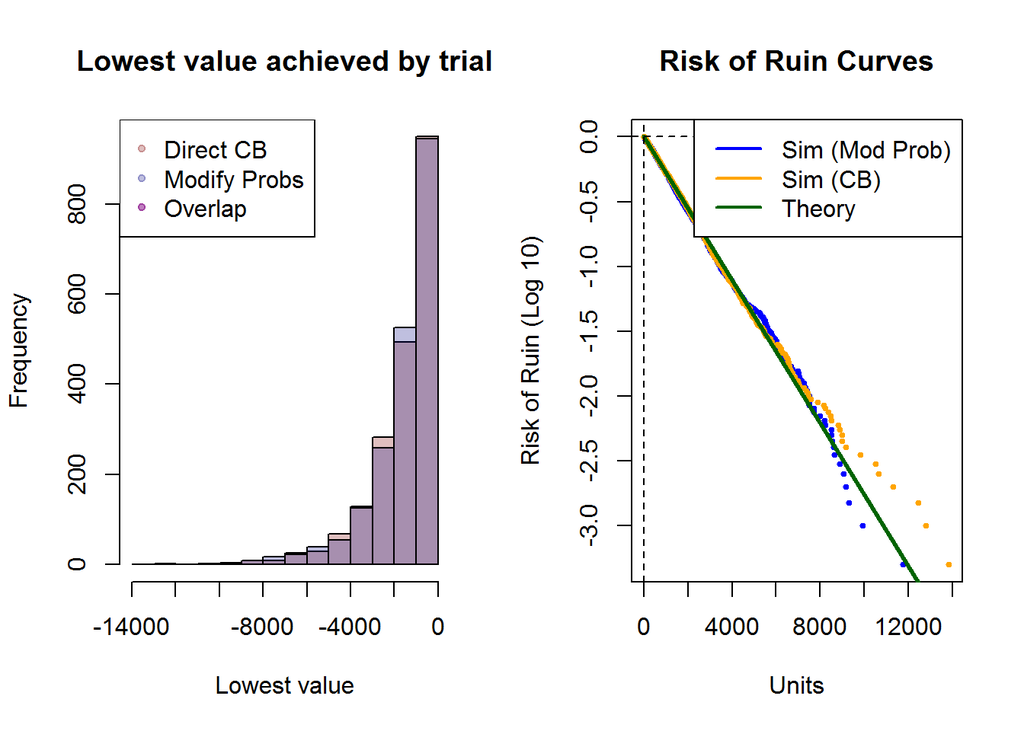

```r
## Step 5c: Plot the simulated results against theory
xMax <- 100 * (ceiling(max(-vecMinNew, -vecMinOrig)/100) + 0)

par(mfrow=c(1,2))

## Left-hand plot
hist(vecMinOrig, col=rgb(0.5, 0, 0, 0.25),
     main="Lowest value achieved by trial", xlab="Lowest value"
     )
hist(vecMinNew, col=rgb(0, 0, 0.5, 0.25), add=TRUE)
legend("topleft", legend=c("Direct CB", "Modify Probs", "Overlap"),
       col=c(rgb(0.5, 0, 0, 0.25), rgb(0, 0, 0.5, 0.25), rgb(0.5, 0, 0.5, 0.5)), pch=20
       )

## Right-hand plot
plot(x=-vecMinNew, y=log10((1:length(vecMinNew))/length(vecMinNew)), xlim=c(0, xMax),
     xlab="Units", ylab="Risk of Ruin (Log 10)", main="Risk of Ruin Curves",
     col="blue", cex=0.75, pch=20
     )
points(x=-vecMinOrig, y=log10((1:length(vecMinOrig))/length(vecMinOrig)),
       col="orange", cex=0.75, pch=20
       )
points(x=0:xMax, y=log10(rr1^(1:(xMax+1))), col="dark green", cex=0.25)
abline(h=0, v=0, lty=2)
legend("topright", legend=c("Sim (Mod Prob)", "Sim (CB)", "Theory"),
       col=c("blue", "orange", "dark green"), lwd=c(2, 2, 2))
```

```r
par(mfrow=c(1,1))
```

Additionally, a chi-squared goodness of fit test is run to investigate whether the simulated data (bucketed) is reasonably aligned to the theoretical data (bucketed).

```r
## Step 5d: Report on the chi-squared goodness of fit
## Create buckets where we expect ~20 observations per bucket
numCuts <- floor(nTrials/20)
cutPts <- numeric(length=numCuts+1)
numPerCutOrig <- numeric(length=numCuts)
numPerCutNew <- numeric(length=numCuts)

for (intCtr in 0:numCuts) {
    cutPts[intCtr+1] <- -log(intCtr/numCuts)/log(rr1)
}

for (intCtr in 1:numCuts) {
    numPerCutOrig[intCtr] <- sum(vecMinOrig > cutPts[intCtr] & vecMinOrig <= cutPts[intCtr+1])
    numPerCutNew[intCtr] <- sum(vecMinNew > cutPts[intCtr] & vecMinNew <= cutPts[intCtr+1])
}

## Overall test (each bucket should in theory be equal size, so default p is OK)
print(chisq.test(numPerCutOrig))
```

```
##
##  Chi-squared test for given probabilities
##
## data:  numPerCutOrig
## X-squared = 80.9, df = 99, p-value = 0.9076
```

```r
print(chisq.test(numPerCutNew))
```

```
##
##  Chi-squared test for given probabilities
##
## data:  numPerCutNew
## X-squared = 104.7, df = 99, p-value = 0.3283
```

#### *Describe the relevant maths*

A few additional mathematical features are calculated and plotted:

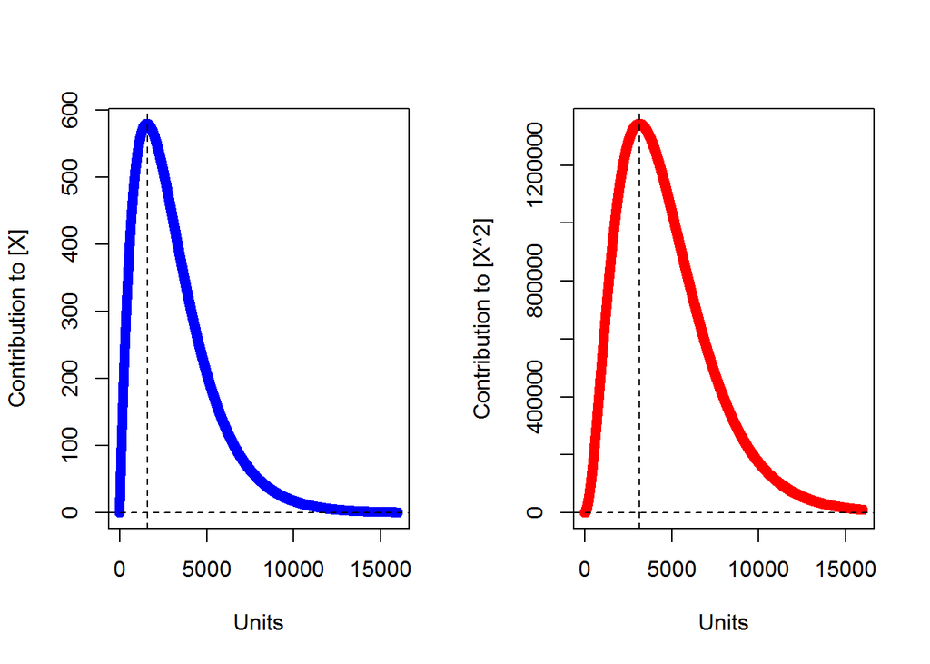

```r
## Describe mathematics
## Probability of ruin for a given n is rr1^n

## Mean would then be (sum-over-1-to-Inf-of n*rr1^n) / (sum-over-1-to-Inf-of rr1^n)
## Peak will be where derivative of n*rr1^n is 0 ; n * rr1^n * ln(rr1) + rr1^n = 0
## Or, rr1^n * (n * ln(rr1) + 1) = 0 OR n = -1 / ln(rr1)

## And, for [X^2] then (sum-over-1-to-Inf-of n^2*rr1^n) / (sum-over-1-to-Inf-of rr1^n)
## Peak will be where derivative of n^2 * rr1^n is 0 ; n^2 * rr1^n * ln(rr1) + 2 * n * rr1^n = 0
## Or, rr1^n * (n^2 * ln(rr1) + 2*n) = 0 OR n = -2 / ln(rr1) [also, trivially, n=0 solves]

par(mfrow=c(1,2))

myX <- 0:16000

plot(myX, myX * rr1^myX, col="blue", xlab="Units", ylab="Contribution to [X]")
abline(h=0, v=-1/log(rr1), lty=2)

plot(myX, myX^2 * rr1^myX, col="red", xlab="Units", ylab="Contribution to [X^2]")
abline(h=0, v=-2/log(rr1), lty=2)
```

```r
par(mfrow=c(1,1))


print("Finished the program:")
```

```
## [1] "Finished the program:"
```

```r
print(proc.time() - startTime)
```

```
##    user  system elapsed
## 1975.52  154.13 2142.34
```